# Predicting a Book’s Goodreads Rating Based on Its Characteristics

Final Project  
Data Science 3 with R (STAT 301-3)

Author

Keshav Srinivasan, Rohan Subramaniam, Hannah Zhao

Published

May 29, 2024

**Project Github Repo Link**

[Final Project Repo Link](https://github.com/stat301-3-2024-spring/final-project-3-rhk)

## **Introduction**

Goodreads has long been used as a method for avid readers to find their next favorite book. They employ a numerical rating of books on a scale of 0-5, rounded to two decimal places. As avid readers, we have always wondered whether a book’s intrinsic characteristics, its Goodreads listing information and its commercial performance, such as its genres, the (number of) awards it has won, the language it was written in and its length in pages. As such, we sought to tackle the regression problem of attempting to predict a book’s overall Goodreads rating using such variables. We did so using a dataset of 52,748 books dubbed “The Best Books Ever” by Goodreads and using it to build predictive models that sought to predict each observation’s overall Goodreads rating.

## **Data Overview**

**Data citation**

Lozano, Lorena C., and Planells, Sergio C., “Best Books Ever.” CSV File, Data set, 2020. https://www.kaggle.com/datasets/thedevastator/comprehensive-overview-of-52478-goodreads-best-b.

[Dataset Link](https://www.kaggle.com/datasets/thedevastator/comprehensive-overview-of-52478-goodreads-best-b)

The dataset used for this project was sourced from Kaggle and contains 52,748 observations representing books. This dataset was found on Kaggle.com, and was previously derived from a data set produced by Lorena Casanova Lozano and Sergio Costa Planells at the Universitat Oberta de Catalunya (UOC).

#### **Target Variable Analysis**

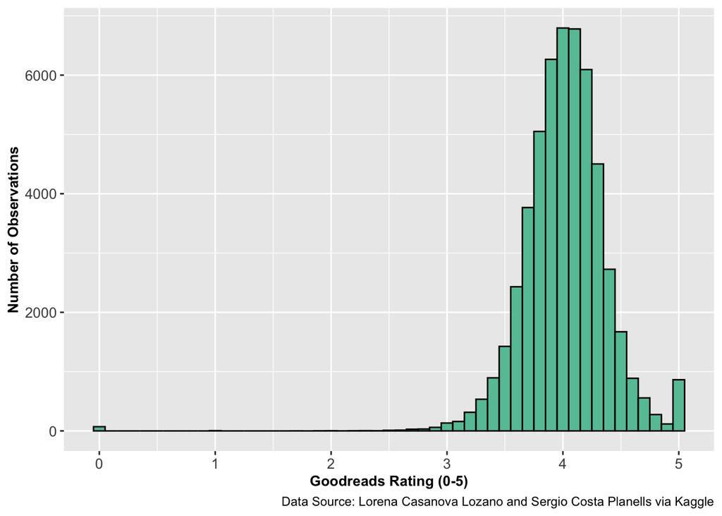

Figure 1: Distribution of the outcome variable, rating

#### **Predictor Variables**

The predictor variables were mainly encoded as character variables, with a few numeric variables. There was a fair amount of missingness in the predictor variables. As well, many of the character variables had unique values for each observation, with each value being a unique list of sub-values; this led to factor variables with very high quantities of levels. See Section 3 and Section 5 for how these character values were cleaned and re-encoded.

## **Methods**

This is a regression problem, since the target variable (`rating`) has a numerical value. Given that this is a regression problem, RMSE (root-mean-squared-error) was used as the assessment metric to test the effectiveness of the models and ultimately was used to select a final model.

For the datasplit, we chose to do a first split the data, with 66% of the data split into a training set named `goodreads_new_training`, and 33% of the data split into an eda set. After this split, we did a second 80/20 split of the new training set, with 80% of the data into a training set `goodreads_train` and 20% of the data into a testing set `goodreads_test`.

The first step to predictive modeling is to conduct cleaning on the dataset. For our initial model building, we performed a very basic cleaning on the dataset, making sure the dates are in a unified format and all character variables were factor encoded. Additionally, we performed the initial split on the dataset, splitting the dataset into training and testing data. The training data is reserved for creating the models and the testing data will be used to test the accuracy of our models. We also used V-fold cross-validation as our resampling technique, using 5 folds or partitions of the training data and 3 repeats of the V-fold partitioning. During this step of the process, we also conduct an extensive data analysis on the ratings variable and the other predictor variables. After analysis and consideration of whether or not transformation would be necessary on the ratings variable to normalize the distribution, we decided against it although it is skewed to the left because the distribution itself is fairly normal, just that few observations had ratings in the 0-3 star range.

The next step was to create the recipes for the models. Our initial process of feature engineering is a “kitchen sink” method of imputation (median imputation for numeric predictors, mode for categorical), re-categorization of rare factor levels, correlation filtering, zero variance filtering and normalization of predictors. We created different recipes for this intial “kitchen sink” method including for random forest, with and without one-hot encoding.

## **Initial Models and Selection**

During the initial model building phase, we constructed and fit the following models:

- k-nearest-neighbor (knn) with `neighbors` tuned from [1,10]
- linear regression (lm)
- elastic net (en) with `penalty` tuned from [-10,0] and `mixture` tuned from [0,1]
- random forest (rf) with `mtry` tuned from [1,24] with 5 levels, `min_n` tuned from [2,40] with 5 levels, and 500 trees
- boosted tree (bt) with `min_n` tuned from [2,40] with 5 levels and `learn_rate` tuned from [-10,-1] with 5 levels
- neural network (nn) with `hidden_units` tuned from [1,10] and `penalty` tuned from [-10,0]
- multivariate adaptive regression splines (mars) with `num_terms` tuned from [1,4] and `prod_degree` tuned from [1,2]
- support vector machines (svm) with `cost` tuned from [-10,5] and `rbf_sigma` tuned from [-10,0]
- ensemble model with random forest (rf) and boosted tree (bt) members with `min_n` tuned from [2,40] with 5 levels, `learn_rate` tuned from [-10,-1] with 5 levels, and `mtry` tuned from [1,24] with 5 levels
- null model (as baseline model)

After fitting all our models, our chosen assessment metric of comparison between the model fits will prioritize RMSE, Root Mean Squared Error.

There were three kitchen sink recipes used in this initial model building phase, with very little/no pre-processing. For the null model (baseline), linear regression (lm), and the mars and svm models, the kitchen sink recipe (`recipe_1`) had `step_dummy(all_nominal_predictors())`, while the k-nearest neighbor (knn), elastic net (en), boosted tree (bt), neural network (nn), and the boosted tree ensemble model used another kitchen sink recipe (`recipe_one_hot`) which added `one_hot = TRUE` into the `step_dummy()`. Lastly, the random forest model (rf) and the random forest ensemble model used a recipe (`recipe_rf`) that did not have `step_dummy()`.

In Figure 2 below, the model metrics for all models in the inital model building phase are shown. The random forest model was the most acccurate with the lowest RSME value (0.16418), the boosted tree model was the second best with a RSME value of 0.16425, and the ensemble model stacking the random forest and boosted tree members was the third best with a RSME value of 0.16900.

These three models, including the random forest (rf), boosted tree (bt), and the ensemble model consisting of rf and bt members performed much better than the other models by a substantial margin. This pattern of tree-based models performing better than linear-based models may show that this data has more non-linear relationships. Tree models map non-linear relationships well, so this shows that this dataset and the target variable `rating` has more non-linear relationships to predictors than linear relationships. For this reason, we continued to the model refinement process with only these three models.

| Model Type | RSME | Standard Error | n |
| --- | --- | --- | --- |
| Null | 0.3698211 | 0.0034448 | 15 |
| Linear Reg. | 0.2489071 | 0.0049271 | 15 |
| Elastic Net | 0.2489040 | 0.0049252 | 15 |
| K-Nearest Neighbors | 0.2585278 | 0.0038881 | 15 |
| Random Forest Tree | 0.1641882 | 0.0010053 | 15 |
| Boosted Tree | 0.1642549 | 0.0011100 | 15 |
| Neural Network | 0.2407219 | 0.0050581 | 15 |
| MARS | 0.2444317 | 0.0047960 | 15 |
| SVM RBF | 0.2412833 | 0.0051260 | 15 |
| Ensemble | 0.1690000 | NA | 15 |

Figure 2: Initial Modeling Building Metrics

## **Model Refinement Process**

In addition, we adjusted all of our recipes so that we used more complex methods of imputation. We used impute_knn and impute_linear on the missingness present in the data. Specifically for our boosted tree recipe, we also included interaction terms on select variables that we noticed a clear relationship in the feature engineering EDA: notably series, rating, num_ratings, bbe_votes, and bbe_score. We also planned to include a step_pca transformation to capture the maximum amount of information (i.e. variance) in the original variables. Therefore, in our complex boosted tree recipe, we also included step_pca (`recipe_fe`)

Given that the three models including boosted tree, random forest tree, and the ensemble with bt and rf members performed much better than the other models in the initial model building phase, these three models were chosen to refine in more depth. Firstly, we used our more complex recipe and newly cleaned dataset to train another random forest model, where we also tuned min_n along [2,40] with 5 levels, and mtry along [1, 20] with 5 levels. This model performed well with a RMSE of 0.192. However this was not improved from the initial random forest model with the kitchen sink recipe and the initial dataset, with a RMSE of 0.16418.

Secondly, also on the newly cleaned dataset, we attempted to use our complex recipe with interaction terms for our boosted tree (named `recipe_fe`). However, after seeing our model run for 48+hours, we realized this was not the most practical way to approach the model refinement for this model.

We ultimately explored different engines in the Boosted Tree Model, and the `lightgbm` engine performed well. On this boosted tree model, we also tuned with min_n along [2,40] with 5 levels, mtry along [1,20] with 5 levels, and learn_rate along [-10,-1] with 5 levels. This model, using the kitchen sink recipe (`recipe_rf`) with the `lightgbm` engine performed very well with an RMSE of 0.191. However, this was not improved from the initial boosted tree model which scored an RMSE of 0.16425 using the kitchen sink recipe, the initial dataset, and the `xgboost` engine.

Thirdly, we wanted to use our more complex recipe (`recipe_bt_fe`) with interactions and step_pca, so we lowered the trees to 500 and tuned min_n along [2,40] with 5 levels, mtry along [1,10] with 5 levels, and learn_rate along [-10,-1] with 5 levels. This performed equally as well as the refined Random Forest Model, with an RMSE of 0.192.

Lastly, we attempted to ensemble the newly refined random forest model and the original boosted tree model on the newly cleaned training data. Originally we attempted to perform an ensemble of these two models on the the more complex recipes, but run time was unrealistically long, so we settled for the less complex recipe (`recipe_bt_ensem`) for this ensemble model for boosted tree. This resulted in an RMSE of 0.194.

In Figure 3 below, all refined model metrics are shown.

| Model Type | RSME | Standard Error | n |
| --- | --- | --- | --- |
| Refined Random Forest | 0.1915203 | 0.0032631 | 15 |
| Lightgbm Boost. Tree | 0.1912640 | 0.0032426 | 15 |
| PCA Boost. Tree | 0.1916170 | 0.0012650 | 15 |
| Ensemble | 0.1940000 | NA | 15 |

Figure 3: Refined Model Metrics

## **Final Model Assessment**

The best model, even after all of the model refinement, was the initial random forest model, using the kitchen sink recipe (`recipe_rf`) and the initial training and testing datasets(`goodreads_train`, `goodreads_test`) and initial folds (`goodreads_folds`). Below, in Figure 4, the final model metrics for this initial random forest model is shown. The r-squared value of 0.863 indicates that 86.3% of the variation in the outcome variable, `rating`, is explained by variation in the predictor variables. This indicates that there a strong predictive correlation between the outcome and predictor variables.

| Metric | Estimator | Value |
| --- | --- | --- |
| rmse | standard | 0.1392397 |
| rsq | standard | 0.8627999 |

Figure 4: Final Model Metrics

Below, in Figure 5, a plot of the observed and predicted Goodreads ratings is shown. The points closely follow the “perfect” trendline, and shows that our final model performed very well in terms of observed rating vs. predicted rating.

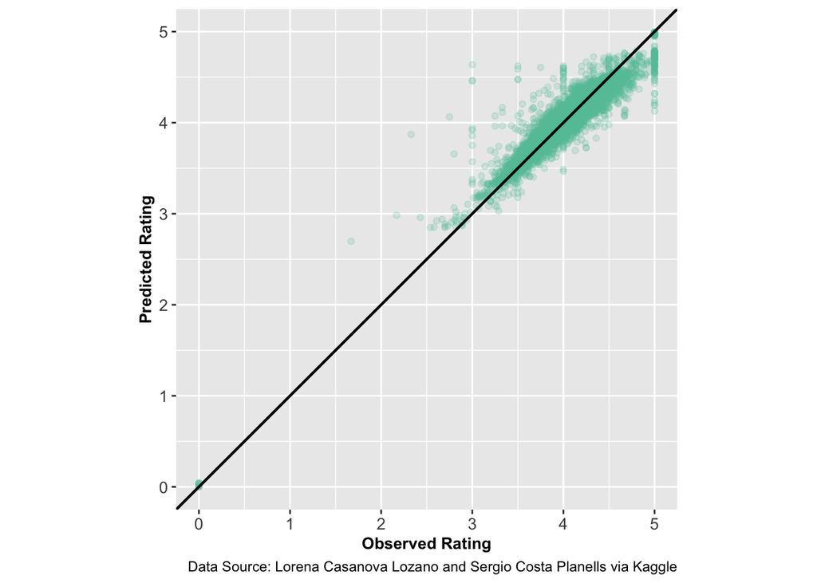

Figure 5: Plot of observed vs. predicted Goodreads Rating values

## **Conclusion**

The most successful predictive model for the ratings variable on Goodreads was the original, “kitchen sink” Random Forest Model from our Initial Model Building.

Although one would think that extensive EDA, detailed data cleaning, personalized recipes, and model hyperparameter fine-tuning/exploration is important to ultimately creating a more accurate predictive model, this project demonstrated that, sometimes, the “kitchen sink” style developed model can turn out to be the most successful in generating predictions. This could have to do with many different reasons. Sometimes, maintaining as much of the raw data and throwing all that information into the model training will be better for predictions than manually altering, cleaning, and fine-tuning the aspects of the model building process. Furthermore, the random forest model type is already a great model for handling kitchen sink data and recipes, because the model has built in interaction searching and handling text-based data processes (which our data had a lot of given that many factors were lists of text).

In conclusion, the predictors in our data do show that the ratings of Goodreads books follow a pattern, meaning that there is a relationship between predictors such as genre, number of pages, author, awards, etc. This makes sense because we do anticipate that ratings of books to change based on certain variables. If the number of awards are higher, it makes sense to expect a higher rating. Certain genres may generate higher ratings. Therefore, this conclusion isn’t surprising.

Opportunities for further exploration include looking into other aspects of the data, potentially even more factor collapsing and cleaning. Some next steps could be exploring the ensemble model by adding non-tree model members. By adding different types of models to include in the ensemble, the performance could be improved.